# What Factors Influence Whether a Terrorist Attack is Successful?

Pablo Dragnic

2026-04-21

## Introduction

The Global Terrorism Database (GTD) records terrorist attacks worldwide from 1970 to 2020. This analysis focuses on **2019** and investigates what factors influence whether a terrorist attack is **successful or not**. According to the GTD codebook, the `success` variable is coded as `1` if the attack achieved its intended effect (e.g., bomb detonated, hostage taken, target killed), and `0` otherwise. This is distinct from strategic success it measures tactical completion.

We examine the following predictor variables:

- **Attack type** (`attacktype1`)
- **Weapon type** (`weaptype1`)
- **Target type** (`targtype1`)
- **Region** (`region`)
- **Suicide attack** (`suicide`)
- **Part of multiple incident** (`multiple`)

We use EDA, chi-square tests, and logistic regression to answer the research question.

## 1. Data Loading and Preparation

```r
library(ggplot2)
library(ezids)
library(pROC)
library(dplyr)
library(knitr)

# Load full dataset and filter to 2019
gtd_full <- read.csv("TerrorData.csv")
terror2019 <- gtd_full[gtd_full$iyear == 2019, ]

# Select relevant columns
terror2019 <- terror2019[, c("success", "attacktype1", "weaptype1", "targtype1",
                              "region", "suicide", "multiple")]

# Convert to factors (numeric codes kept for models)
terror2019$success     <- as.factor(terror2019$success)
terror2019$attacktype1 <- as.factor(terror2019$attacktype1)
terror2019$weaptype1   <- as.factor(terror2019$weaptype1)
terror2019$targtype1   <- as.factor(terror2019$targtype1)
terror2019$region      <- as.factor(terror2019$region)
terror2019$suicide     <- as.factor(terror2019$suicide)
terror2019$multiple    <- as.factor(terror2019$multiple)

# Labeled versions for readable plots
attack_labels <- c("1"="Assassination","2"="Armed Assault","3"="Bombing/Explosion",
                   "4"="Hijacking","5"="Barricade Incident","6"="Kidnapping",
                   "7"="Facility Attack","8"="Unarmed Assault","9"="Unknown")
weapon_labels <- c("1"="Biological","2"="Chemical","5"="Firearms","6"="Explosives",
                   "8"="Incendiary","9"="Melee","10"="Vehicle","11"="Sabotage",
                   "12"="Other","13"="Unknown")
region_labels <- c("1"="North America","2"="Cent. America & Caribbean",
                   "3"="South America","4"="East Asia","5"="Southeast Asia",
                   "6"="South Asia","7"="Central Asia","8"="Western Europe",
                   "9"="Eastern Europe","10"="Middle East & N. Africa",
                   "11"="Sub-Saharan Africa","12"="Australasia & Oceania")
targ_labels   <- c("1"="Business","2"="Government (General)","3"="Police",
                   "4"="Military","5"="Abortion Related","6"="Airports & Aircraft",
                   "7"="Government (Diplomatic)","8"="Educational Institution",
                   "9"="Food/Water Supply","10"="Journalists & Media",
                   "11"="Maritime","12"="NGO","13"="Other",
                   "14"="Private Citizens","15"="Religious","16"="Telecom",
                   "17"="Terrorists/Militias","18"="Tourists",
                   "19"="Transportation","20"="Unknown","21"="Utilities",
                   "22"="Violent Political Parties")

terror2019$attack_lbl <- attack_labels[as.character(terror2019$attacktype1)]
terror2019$weapon_lbl <- weapon_labels[as.character(terror2019$weaptype1)]
terror2019$region_lbl <- region_labels[as.character(terror2019$region)]
terror2019$targ_lbl   <- targ_labels[as.character(terror2019$targtype1)]

str(terror2019)
```

```
## 'data.frame':    8536 obs. of  11 variables:
##  $ success    : Factor w/ 2 levels "0","1": 2 2 1 2 2 1 2 2 2 2 ...
##  $ attacktype1: Factor w/ 9 levels "1","2","3","4",..: 3 3 1 2 2 1 2 2 3 2 ...
##  $ weaptype1  : Factor w/ 10 levels "1","2","5","6",..: 4 4 4 3 3 4 3 3 4 3 ...
##  $ targtype1  : Factor w/ 21 levels "1","2","3","4",..: 4 4 2 3 3 2 3 13 3 14 ...
##  $ region     : Factor w/ 12 levels "1","2","3","4",..: 11 6 5 5 6 5 6 11 10 8 ...
##  $ suicide    : Factor w/ 2 levels "0","1": 1 1 1 1 1 1 1 1 2 1 ...
##  $ multiple   : Factor w/ 2 levels "0","1": 2 1 1 1 1 1 1 1 2 1 ...
##  $ attack_lbl : chr  "Bombing/Explosion" "Bombing/Explosion" "Assassination" "Armed Assault" ...
##  $ weapon_lbl : chr  "Explosives" "Explosives" "Explosives" "Firearms" ...
##  $ region_lbl : chr  "Sub-Saharan Africa" "South Asia" "Southeast Asia" "Southeast Asia" ...
##  $ targ_lbl   : chr  "Military" "Military" "Government (General)" "Police" ...
```

## 2. Exploratory Data Analysis

### 2.1 Overall Success Rate

```r
total    <- nrow(terror2019)
n_succ   <- sum(terror2019$success == 1)
n_unsucc <- sum(terror2019$success == 0)

cat("Total attacks in 2019:", total, "\n")
```

```
## Total attacks in 2019: 8536
```

```r
cat("Successful attacks:", n_succ, "(", round(n_succ/total*100, 1), "%)\n")
```

```
## Successful attacks: 7330 ( 85.9 %)
```

```r
cat("Unsuccessful attacks:", n_unsucc, "(", round(n_unsucc/total*100, 1), "%)\n")
```

```
## Unsuccessful attacks: 1206 ( 14.1 %)
```

In 2019, the vast majority of recorded attacks were successful. The `success` variable is imbalanced, which we will keep in mind when interpreting model results.

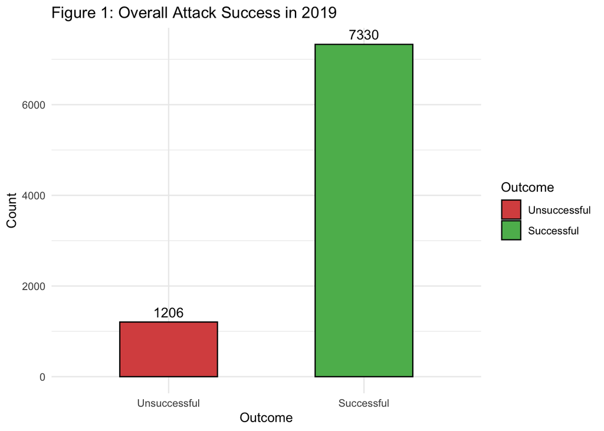

```r
ggplot(terror2019, aes(x = success, fill = success)) +
  geom_bar(color = "black", width = 0.5) +
  geom_text(stat = "count", aes(label = ..count..), vjust = -0.5, size = 4) +
  scale_fill_manual(values = c("0" = "#d9534f", "1" = "#5cb85c"),
                    labels = c("Unsuccessful", "Successful")) +
  scale_x_discrete(labels = c("0" = "Unsuccessful", "1" = "Successful")) +
  labs(title = "Figure 1: Overall Attack Success in 2019",
       x = "Outcome", y = "Count", fill = "Outcome") +
  theme_minimal()
```

### 2.2 Success by Attack Type

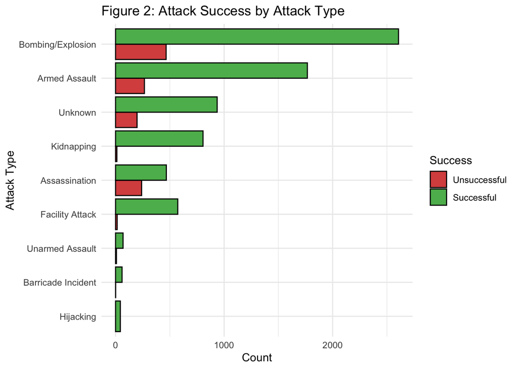

```r
ggplot(terror2019, aes(x = reorder(attack_lbl, table(attack_lbl)[attack_lbl]),
                       fill = success)) +
  geom_bar(position = "dodge", color = "black") +
  scale_fill_manual(values = c("0" = "#d9534f", "1" = "#5cb85c"),
                    labels = c("Unsuccessful", "Successful")) +
  coord_flip() +
  labs(title = "Figure 2: Attack Success by Attack Type",
       x = "Attack Type", y = "Count", fill = "Success") +
  theme_minimal()
```

### 2.3 Success by Weapon Type

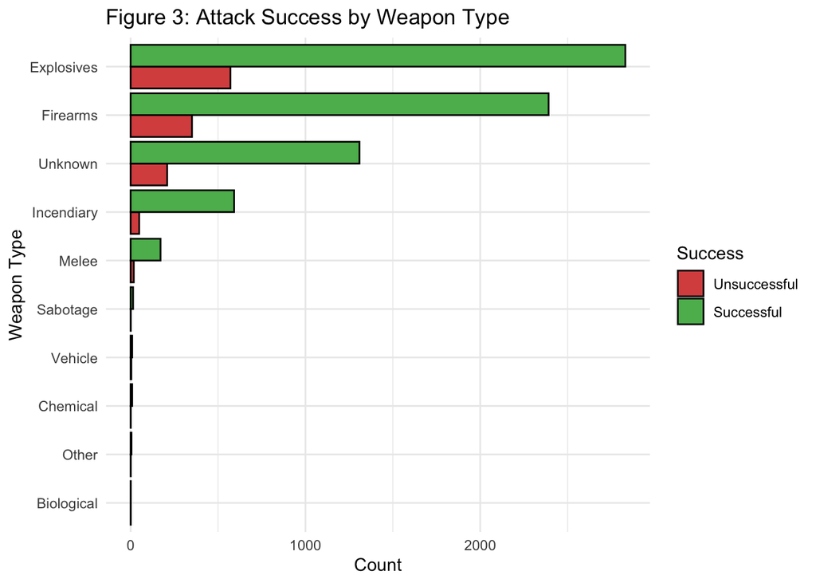

```r
ggplot(terror2019, aes(x = reorder(weapon_lbl, table(weapon_lbl)[weapon_lbl]),
                       fill = success)) +
  geom_bar(position = "dodge", color = "black") +
  scale_fill_manual(values = c("0" = "#d9534f", "1" = "#5cb85c"),
                    labels = c("Unsuccessful", "Successful")) +
  coord_flip() +
  labs(title = "Figure 3: Attack Success by Weapon Type",
       x = "Weapon Type", y = "Count", fill = "Success") +
  theme_minimal()
```

Weapon type codes: 1=Biological, 2=Chemical, 5=Firearms, 6=Explosives, 8=Incendiary, 9=Melee, 10=Vehicle, 11=Sabotage, 12=Other, 13=Unknown.

### 2.4 Success by Region

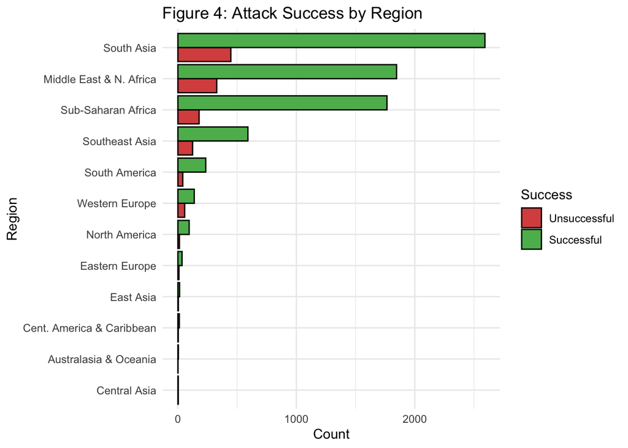

```r
ggplot(terror2019, aes(x = reorder(region_lbl, table(region_lbl)[region_lbl]),
                       fill = success)) +
  geom_bar(position = "dodge", color = "black") +
  scale_fill_manual(values = c("0" = "#d9534f", "1" = "#5cb85c"),
                    labels = c("Unsuccessful", "Successful")) +
  coord_flip() +
  labs(title = "Figure 4: Attack Success by Region",
       x = "Region", y = "Count", fill = "Success") +
  theme_minimal()
```

### 2.4b Success by Target Type

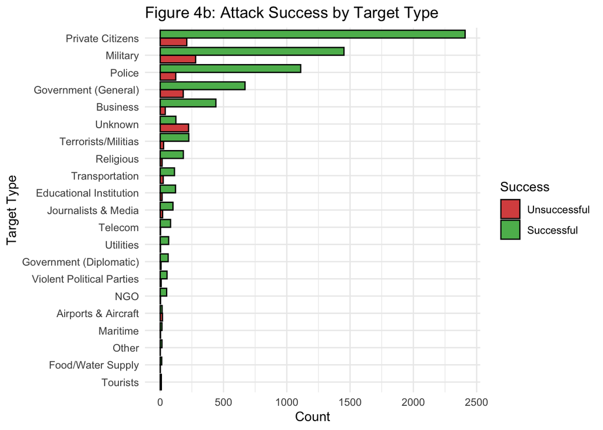

```r
ggplot(terror2019, aes(x = reorder(targ_lbl, table(targ_lbl)[targ_lbl]),
                       fill = success)) +
  geom_bar(position = "dodge", color = "black") +
  scale_fill_manual(values = c("0" = "#d9534f", "1" = "#5cb85c"),
                    labels = c("Unsuccessful", "Successful")) +
  coord_flip() +
  labs(title = "Figure 4b: Attack Success by Target Type",
       x = "Target Type", y = "Count", fill = "Success") +
  theme_minimal()
```

### 2.5 Success by Suicide Attack

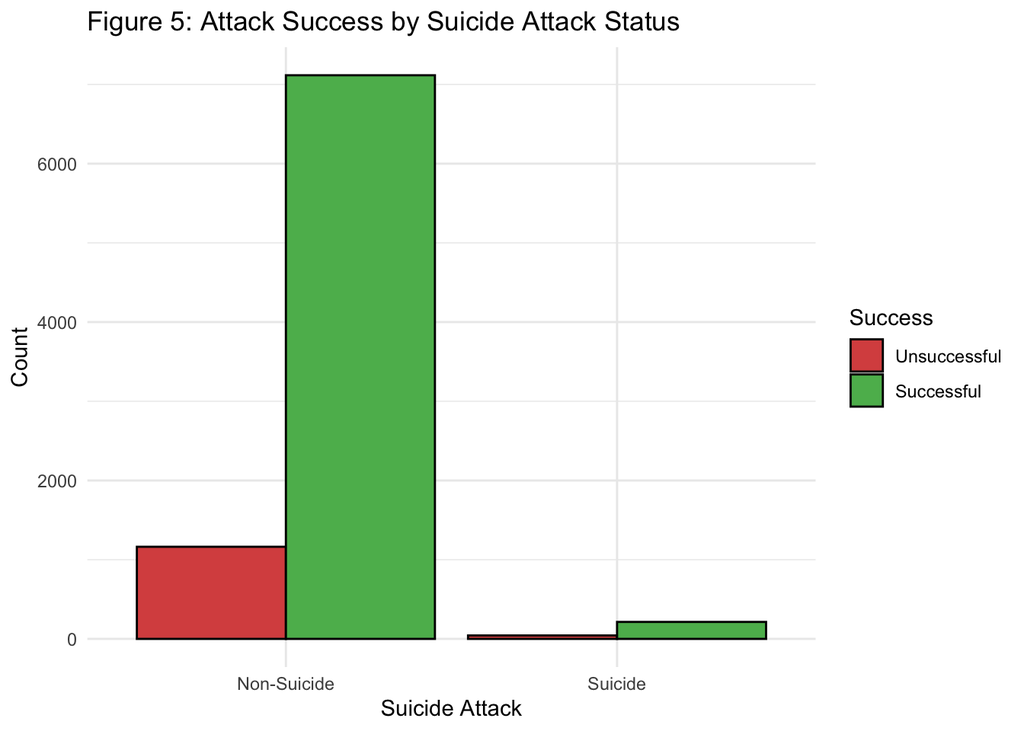

```r
ggplot(terror2019, aes(x = suicide, fill = success)) +
  geom_bar(position = "dodge", color = "black") +
  scale_fill_manual(values = c("0" = "#d9534f", "1" = "#5cb85c"),
                    labels = c("Unsuccessful", "Successful")) +
  scale_x_discrete(labels = c("0" = "Non-Suicide", "1" = "Suicide")) +
  labs(title = "Figure 5: Attack Success by Suicide Attack Status",
       x = "Suicide Attack", y = "Count", fill = "Success") +
  theme_minimal()
```

### 2.6 Success by Multiple Incident

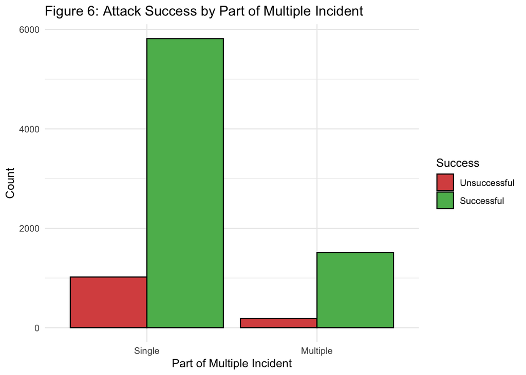

```r
ggplot(terror2019, aes(x = multiple, fill = success)) +
  geom_bar(position = "dodge", color = "black") +
  scale_fill_manual(values = c("0" = "#d9534f", "1" = "#5cb85c"),
                    labels = c("Unsuccessful", "Successful")) +
  scale_x_discrete(labels = c("0" = "Single", "1" = "Multiple")) +
  labs(title = "Figure 6: Attack Success by Part of Multiple Incident",
       x = "Part of Multiple Incident", y = "Count", fill = "Success") +
  theme_minimal()
```

## 3. Chi-Square Tests

For each predictor, we test whether it is independent of attack success. Alpha = 0.05 throughout.

### 3.1 Attack Type vs. Success

**H0:** Attack type and success are independent.  
**H1:** Attack type and success are not independent.

```r
contable_att <- table(terror2019$success, terror2019$attacktype1)
xkabledply(contable_att, title = "Contingency Table: Success vs. Attack Type")
```

Contingency Table: Success vs. Attack Type

|  | 1 | 2 | 3 | 4 | 5 | 6 | 7 | 8 | 9 |
| --- | --- | --- | --- | --- | --- | --- | --- | --- | --- |
| 0 | 240 | 266 | 466 | 0 | 1 | 12 | 15 | 8 | 198 |
| 1 | 468 | 1767 | 2607 | 44 | 60 | 806 | 573 | 69 | 936 |

```r
chisq.test(contable_att)
```

```
##
##  Pearson's Chi-squared test
##
## data:  contable_att
## X-squared = 432.03, df = 8, p-value < 2.2e-16
```

### 3.2 Weapon Type vs. Success

**H0:** Weapon type and success are independent.  
**H1:** Weapon type and success are not independent.

```r
contable_wep <- table(terror2019$success, terror2019$weaptype1)
xkabledply(contable_wep, title = "Contingency Table: Success vs. Weapon Type")
```

Contingency Table: Success vs. Weapon Type

|  | 1 | 2 | 5 | 6 | 8 | 9 | 10 | 11 | 12 | 13 |
| --- | --- | --- | --- | --- | --- | --- | --- | --- | --- | --- |
| 0 | 1 | 1 | 351 | 571 | 49 | 18 | 4 | 1 | 1 | 209 |
| 1 | 0 | 9 | 2391 | 2830 | 592 | 171 | 9 | 14 | 5 | 1309 |

```r
chisq.test(contable_wep)
```

```
##
##  Pearson's Chi-squared test
##
## data:  contable_wep
## X-squared = 59.414, df = 9, p-value = 1.738e-09
```

### 3.3 Target Type vs. Success

**H0:** Target type and success are independent.  
**H1:** Target type and success are not independent.

```r
contable_targ <- table(terror2019$success, terror2019$targtype1)
xkabledply(contable_targ, title = "Contingency Table: Success vs. Target Type")
```

Contingency Table: Success vs. Target Type

|  | 1 | 2 | 3 | 4 | 6 | 7 | 8 | 9 | 10 | 11 | 12 | 13 | 14 | 15 | 16 | 17 | 18 | 19 | 20 | 21 | 22 |
| --- | --- | --- | --- | --- | --- | --- | --- | --- | --- | --- | --- | --- | --- | --- | --- | --- | --- | --- | --- | --- | --- |
| 0 | 40 | 182 | 123 | 280 | 18 | 7 | 15 | 1 | 19 | 3 | 3 | 1 | 210 | 15 | 3 | 27 | 0 | 24 | 224 | 3 | 8 |
| 1 | 440 | 670 | 1110 | 1452 | 15 | 63 | 121 | 12 | 101 | 14 | 51 | 14 | 2409 | 183 | 82 | 226 | 9 | 113 | 124 | 67 | 54 |

```r
chisq.test(contable_targ)
```

```
##
##  Pearson's Chi-squared test
##
## data:  contable_targ
## X-squared = 955.22, df = 20, p-value < 2.2e-16
```

### 3.4 Region vs. Success

**H0:** Region and success are independent.  
**H1:** Region and success are not independent.

```r
contable_reg <- table(terror2019$success, terror2019$region)
xkabledply(contable_reg, title = "Contingency Table: Success vs. Region")
```

Contingency Table: Success vs. Region

|  | 1 | 2 | 3 | 4 | 5 | 6 | 7 | 8 | 9 | 10 | 11 | 12 |
| --- | --- | --- | --- | --- | --- | --- | --- | --- | --- | --- | --- | --- |
| 0 | 13 | 3 | 41 | 4 | 124 | 447 | 0 | 57 | 9 | 328 | 179 | 1 |
| 1 | 95 | 12 | 235 | 14 | 591 | 2592 | 3 | 138 | 35 | 1846 | 1765 | 4 |

```r
chisq.test(contable_reg)
```

```
##
##  Pearson's Chi-squared test
##
## data:  contable_reg
## X-squared = 88.03, df = 11, p-value = 4.05e-14
```

### 3.5 Suicide vs. Success

**H0:** Suicide attack status and success are independent.  
**H1:** Suicide attack status and success are not independent.

```r
contable_sui <- table(terror2019$success, terror2019$suicide)
xkabledply(contable_sui, title = "Contingency Table: Success vs. Suicide")
```

Contingency Table: Success vs. Suicide

|  | 0 | 1 |
| --- | --- | --- |
| 0 | 1163 | 43 |
| 1 | 7116 | 214 |

```r
chisq.test(contable_sui)
```

```
##
##  Pearson's Chi-squared test with Yates' continuity correction
##
## data:  contable_sui
## X-squared = 1.267, df = 1, p-value = 0.2603
```

### 3.6 Multiple Incident vs. Success

**H0:** Part of multiple incident and success are independent.  
**H1:** Part of multiple incident and success are not independent.

```r
contable_mul <- table(terror2019$success, terror2019$multiple)
xkabledply(contable_mul, title = "Contingency Table: Success vs. Multiple Incident")
```

Contingency Table: Success vs. Multiple Incident

|  | 0 | 1 |
| --- | --- | --- |
| 0 | 1021 | 185 |
| 1 | 5816 | 1514 |

```r
chisq.test(contable_mul)
```

```
##
##  Pearson's Chi-squared test with Yates' continuity correction
##
## data:  contable_mul
## X-squared = 18.018, df = 1, p-value = 2.188e-05
```

## 4. Logistic Regression

Since `success` is a binary outcome, we use logistic regression (GLM with binomial family). We build and compare three models of increasing complexity. A helper function is defined to extract clean performance metrics from each model.

```r
library(knitr)
library(kableExtra)

# Master label lookup: maps raw coefficient names -> readable labels
label_map <- c(
  "(Intercept)"    = "(Intercept)",
  # Attack type
  "attacktype12"   = "Attack: Armed Assault",
  "attacktype13"   = "Attack: Bombing/Explosion",
  "attacktype14"   = "Attack: Hijacking",
  "attacktype15"   = "Attack: Barricade Incident",
  "attacktype16"   = "Attack: Kidnapping",
  "attacktype17"   = "Attack: Facility Attack",
  "attacktype18"   = "Attack: Unarmed Assault",
  "attacktype19"   = "Attack: Unknown",
  # Weapon type
  "weaptype12"     = "Weapon: Chemical",
  "weaptype15"     = "Weapon: Firearms",
  "weaptype16"     = "Weapon: Explosives",
  "weaptype18"     = "Weapon: Incendiary",
  "weaptype19"     = "Weapon: Melee",
  "weaptype110"    = "Weapon: Vehicle",
  "weaptype111"    = "Weapon: Sabotage",
  "weaptype112"    = "Weapon: Other",
  "weaptype113"    = "Weapon: Unknown",
  # Target type
  "targtype12"     = "Target: Government (General)",
  "targtype13"     = "Target: Police",
  "targtype14"     = "Target: Military",
  "targtype15"     = "Target: Abortion Related",
  "targtype16"     = "Target: Airports & Aircraft",
  "targtype17"     = "Target: Government (Diplomatic)",
  "targtype18"     = "Target: Educational Institution",
  "targtype19"     = "Target: Food/Water Supply",
  "targtype110"    = "Target: Journalists & Media",
  "targtype111"    = "Target: Maritime",
  "targtype112"    = "Target: NGO",
  "targtype113"    = "Target: Other",
  "targtype114"    = "Target: Private Citizens",
  "targtype115"    = "Target: Religious",
  "targtype116"    = "Target: Telecom",
  "targtype117"    = "Target: Terrorists/Militias",
  "targtype118"    = "Target: Tourists",
  "targtype119"    = "Target: Transportation",
  "targtype120"    = "Target: Unknown",
  "targtype121"    = "Target: Utilities",
  "targtype122"    = "Target: Violent Political Parties",
  # Region
  "region2"        = "Region: Cent. America & Caribbean",
  "region3"        = "Region: South America",
  "region4"        = "Region: East Asia",
  "region5"        = "Region: Southeast Asia",
  "region6"        = "Region: South Asia",
  "region7"        = "Region: Central Asia",
  "region8"        = "Region: Western Europe",
  "region9"        = "Region: Eastern Europe",
  "region10"       = "Region: Middle East & N. Africa",
  "region11"       = "Region: Sub-Saharan Africa",
  "region12"       = "Region: Australasia & Oceania",
  # Suicide / multiple
  "suicide1"       = "Suicide Attack: Yes",
  "multiple1"      = "Part of Multiple Incident: Yes"
)

# Helper: formatted coefficient table with OR and 95% CI
coef_table <- function(model, title = "Coefficient Table") {
  s      <- summary(model)$coefficients
  or     <- exp(s[, 1])
  ci     <- exp(confint.default(model))
  df_out <- data.frame(
    Predictor    = ifelse(rownames(s) %in% names(label_map),
                          label_map[rownames(s)], rownames(s)),
    Coefficient  = round(s[, 1], 4),
    Std.Error    = round(s[, 2], 4),
    z.value      = round(s[, 3], 4),
    p.value      = round(s[, 4], 4),
    OR           = round(or, 4),
    CI_lower_95  = round(ci[, 1], 4),
    CI_upper_95  = round(ci[, 2], 4)
  )
  rownames(df_out) <- NULL
  kable(df_out, caption = title) %>%
    kable_styling(bootstrap_options = c("striped", "hover", "condensed"),
                  full_width = FALSE, font_size = 12)
}

# Helper: confusion matrix metrics table (handles incomplete matrices)
conf_metrics <- function(pred, actual, model_name = "Model") {
  cm   <- table(factor(pred, levels = c(0,1)),
                factor(actual, levels = c(0,1)))
  TN   <- cm[1, 1]; FP <- cm[2, 1]
  FN   <- cm[1, 2]; TP <- cm[2, 2]
  acc  <- round((TP + TN) / sum(cm), 4)
  sens <- round(TP  / (TP + FN), 4)
  spec <- round(TN  / (TN + FP), 4)
  prec <- ifelse((TP + FP) == 0, NA, round(TP / (TP + FP), 4))
  f1   <- ifelse(is.na(prec), NA, round(2 * prec * sens / (prec + sens), 4))
  data.frame(Model       = model_name,
             Accuracy    = acc,
             Sensitivity = sens,
             Specificity = spec,
             Precision   = prec,
             F1_Score    = f1)
}
```

### 4.1 Model 1: Full Model (All Predictors)

```r
model1 <- glm(success ~ attacktype1 + weaptype1 + targtype1 + region + suicide + multiple,
              data = terror2019, family = binomial)
```

**Table 8: Coefficients, Odds Ratios, and 95% CI Model 1**

```r
coef_table(model1, title = "Table 8: Model 1  Coefficients, OR, and 95% CI")
```

Table 8: Model 1 Coefficients, OR, and 95% CI

| Predictor | Coefficient | Std.Error | z.value | p.value | OR | CI_lower_95 | CI_upper_95 |
| --- | --- | --- | --- | --- | --- | --- | --- |
| (Intercept) | -18.1636 | 1455.3977 | -0.0125 | 0.9900 | 0.000000e+00 | 0.0000 | Inf |
| Attack: Armed Assault | 1.2086 | 0.1319 | 9.1611 | 0.0000 | 3.348700e+00 | 2.5857 | 4.336900e+00 |
| Attack: Bombing/Explosion | 2.2361 | 0.1594 | 14.0319 | 0.0000 | 9.357000e+00 | 6.8468 | 1.278750e+01 |
| Attack: Hijacking | 15.1390 | 203.6149 | 0.0744 | 0.9407 | 3.756347e+06 | 0.0000 | 7.800374e+179 |
| Attack: Barricade Incident | 3.4381 | 1.0203 | 3.3698 | 0.0008 | 3.112800e+01 | 4.2140 | 2.299356e+02 |
| Attack: Kidnapping | 3.1779 | 0.3186 | 9.9761 | 0.0000 | 2.399730e+01 | 12.8531 | 4.480400e+01 |
| Attack: Facility Attack | 3.7348 | 0.3678 | 10.1532 | 0.0000 | 4.187820e+01 | 20.3648 | 8.611850e+01 |
| Attack: Unarmed Assault | 2.9830 | 0.6994 | 4.2649 | 0.0000 | 1.974750e+01 | 5.0136 | 7.778060e+01 |
| Attack: Unknown | -0.0150 | 0.3562 | -0.0421 | 0.9664 | 9.851000e-01 | 0.4901 | 1.979900e+00 |
| Weapon: Chemical | 17.3234 | 1455.3979 | 0.0119 | 0.9905 | 3.337804e+07 | 0.0000 | Inf |
| Weapon: Firearms | 18.8796 | 1455.3977 | 0.0130 | 0.9897 | 1.582297e+08 | 0.0000 | Inf |
| Weapon: Explosives | 18.2687 | 1455.3977 | 0.0126 | 0.9900 | 8.589830e+07 | 0.0000 | Inf |
| Weapon: Incendiary | 18.1836 | 1455.3977 | 0.0125 | 0.9900 | 7.889326e+07 | 0.0000 | Inf |
| Weapon: Melee | 18.7300 | 1455.3977 | 0.0129 | 0.9897 | 1.362549e+08 | 0.0000 | Inf |
| Weapon: Vehicle | 16.3541 | 1455.3976 | 0.0112 | 0.9910 | 1.266196e+07 | 0.0000 | Inf |
| Weapon: Sabotage | 16.9482 | 1455.3981 | 0.0116 | 0.9907 | 2.293672e+07 | 0.0000 | Inf |
| Weapon: Other | 17.7701 | 1455.3980 | 0.0122 | 0.9903 | 5.217544e+07 | 0.0000 | Inf |
| Weapon: Unknown | 19.5856 | 1455.3977 | 0.0135 | 0.9893 | 3.205778e+08 | 0.0000 | Inf |
| Target: Government (General) | -0.1503 | 0.2071 | -0.7258 | 0.4680 | 8.604000e-01 | 0.5734 | 1.291200e+00 |
| Target: Police | 0.4707 | 0.2023 | 2.3266 | 0.0200 | 1.601200e+00 | 1.0770 | 2.380500e+00 |
| Target: Military | -0.1778 | 0.1881 | -0.9454 | 0.3444 | 8.371000e-01 | 0.5790 | 1.210200e+00 |
| Target: Airports & Aircraft | -2.2750 | 0.4008 | -5.6758 | 0.0000 | 1.028000e-01 | 0.0469 | 2.255000e-01 |
| Target: Government (Diplomatic) | 0.1944 | 0.4561 | 0.4262 | 0.6700 | 1.214600e+00 | 0.4968 | 2.969400e+00 |
| Target: Educational Institution | -0.3778 | 0.3328 | -1.1353 | 0.2563 | 6.854000e-01 | 0.3570 | 1.315800e+00 |
| Target: Food/Water Supply | -0.3182 | 1.0728 | -0.2966 | 0.7667 | 7.274000e-01 | 0.0888 | 5.956000e+00 |
| Target: Journalists & Media | 0.3350 | 0.3400 | 0.9851 | 0.3246 | 1.397900e+00 | 0.7178 | 2.722200e+00 |
| Target: Maritime | -1.6397 | 0.7312 | -2.2425 | 0.0249 | 1.940000e-01 | 0.0463 | 8.134000e-01 |
| Target: NGO | 0.4680 | 0.6327 | 0.7397 | 0.4595 | 1.596800e+00 | 0.4620 | 5.519000e+00 |
| Target: Other | 0.2786 | 1.0594 | 0.2630 | 0.7926 | 1.321300e+00 | 0.1657 | 1.053830e+01 |
| Target: Private Citizens | 0.4097 | 0.1889 | 2.1690 | 0.0301 | 1.506400e+00 | 1.0403 | 2.181500e+00 |
| Target: Religious | 0.3419 | 0.3335 | 1.0251 | 0.3053 | 1.407600e+00 | 0.7321 | 2.706400e+00 |
| Target: Telecom | -0.0551 | 0.6596 | -0.0835 | 0.9334 | 9.464000e-01 | 0.2598 | 3.447700e+00 |
| Target: Terrorists/Militias | 0.5546 | 0.2756 | 2.0122 | 0.0442 | 1.741300e+00 | 1.0145 | 2.988700e+00 |
| Target: Tourists | 13.1538 | 460.9263 | 0.0285 | 0.9772 | 5.159824e+05 | 0.0000 | Inf |
| Target: Transportation | -0.8494 | 0.2886 | -2.9426 | 0.0033 | 4.277000e-01 | 0.2429 | 7.530000e-01 |
| Target: Unknown | -2.8649 | 0.2108 | -13.5908 | 0.0000 | 5.700000e-02 | 0.0377 | 8.610000e-02 |
| Target: Utilities | 0.7763 | 0.6251 | 1.2418 | 0.2143 | 2.173400e+00 | 0.6383 | 7.400200e+00 |
| Target: Violent Political Parties | 0.7510 | 0.4398 | 1.7076 | 0.0877 | 2.119100e+00 | 0.8950 | 5.017400e+00 |
| Region: Cent. America & Caribbean | 0.4231 | 0.7722 | 0.5480 | 0.5837 | 1.526700e+00 | 0.3361 | 6.934600e+00 |
| Region: South America | -0.2160 | 0.3914 | -0.5519 | 0.5811 | 8.057000e-01 | 0.3741 | 1.735300e+00 |
| Region: East Asia | -1.0519 | 0.7099 | -1.4817 | 0.1384 | 3.493000e-01 | 0.0869 | 1.404200e+00 |
| Region: Southeast Asia | -0.0194 | 0.3574 | -0.0543 | 0.9567 | 9.808000e-01 | 0.4868 | 1.975900e+00 |
| Region: South Asia | -0.0049 | 0.3476 | -0.0142 | 0.9887 | 9.951000e-01 | 0.5034 | 1.966900e+00 |
| Region: Central Asia | 13.1548 | 808.1868 | 0.0163 | 0.9870 | 5.164858e+05 | 0.0000 | Inf |
| Region: Western Europe | -1.4587 | 0.3839 | -3.8001 | 0.0001 | 2.325000e-01 | 0.1096 | 4.934000e-01 |
| Region: Eastern Europe | -0.7071 | 0.5375 | -1.3156 | 0.1883 | 4.931000e-01 | 0.1720 | 1.413900e+00 |
| Region: Middle East & N. Africa | -0.2352 | 0.3488 | -0.6742 | 0.5002 | 7.904000e-01 | 0.3990 | 1.565900e+00 |
| Region: Sub-Saharan Africa | 0.2216 | 0.3522 | 0.6291 | 0.5293 | 1.248000e+00 | 0.6258 | 2.488700e+00 |
| Region: Australasia & Oceania | -1.7757 | 1.2266 | -1.4476 | 0.1477 | 1.694000e-01 | 0.0153 | 1.874700e+00 |
| Suicide Attack: Yes | -0.1882 | 0.2014 | -0.9345 | 0.3500 | 8.285000e-01 | 0.5583 | 1.229400e+00 |
| Part of Multiple Incident: Yes | 0.1880 | 0.0956 | 1.9653 | 0.0494 | 1.206800e+00 | 1.0005 | 1.455600e+00 |

**Confusion Matrix and Performance Metrics Model 1:**

```r
probs1 <- predict(model1, type = "response")
pred1  <- ifelse(probs1 > 0.5, 1, 0)
cm1    <- table(Predicted = pred1, Actual = terror2019$success)
xkabledply(cm1, title = "Confusion Matrix  Model 1")
```

Confusion Matrix Model 1

|  | 0 | 1 |
| --- | --- | --- |
| 0 | 292 | 152 |
| 1 | 914 | 7178 |

```r
metrics1 <- conf_metrics(pred1, terror2019$success, "Model 1 (Full)")
kable(metrics1, caption = "Table 9: Performance Metrics  Model 1") %>%
  kable_styling(bootstrap_options = c("striped", "hover"), full_width = FALSE)
```

Table 9: Performance Metrics Model 1

| Model | Accuracy | Sensitivity | Specificity | Precision | F1_Score |
| --- | --- | --- | --- | --- | --- |
| Model 1 (Full) | 0.8751 | 0.9793 | 0.2421 | 0.887 | 0.9309 |

**ROC Curve and AUC Model 1:**

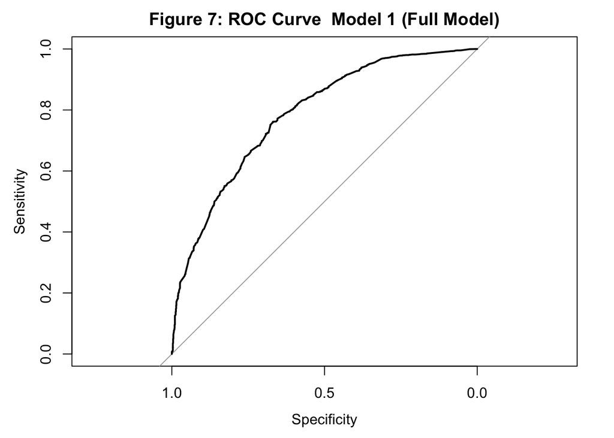

```r
roc1  <- roc(terror2019$success, probs1)
plot(roc1, main = "Figure 7: ROC Curve  Model 1 (Full Model)")
```

```r
best1 <- coords(roc1, "best", ret = c("threshold", "sensitivity", "specificity"),
                best.method = "youden")
kable(as.data.frame(best1), digits = 4,
      caption = "Table 10: Best Threshold (Youden)  Model 1") %>%
  kable_styling(bootstrap_options = c("striped", "hover"), full_width = FALSE)
```

Table 10: Best Threshold (Youden) Model 1

| threshold | sensitivity | specificity |
| --- | --- | --- |
| 0.8548 | 0.7614 | 0.6692 |

```r
cat("AUC Model 1:", round(auc(roc1), 4), "\n")
```

```
## AUC Model 1: 0.7838
```

### 4.2 Model 2: Reduced Model (Attack Type + Weapon Type + Region + Suicide)

```r
model2 <- glm(success ~ attacktype1 + weaptype1 + region + suicide,
              data = terror2019, family = binomial)
```

**Table 11: Coefficients, Odds Ratios, and 95% CI Model 2**

```r
coef_table(model2, title = "Table 11: Model 2  Coefficients, OR, and 95% CI")
```

Table 11: Model 2 Coefficients, OR, and 95% CI

| Predictor | Coefficient | Std.Error | z.value | p.value | OR | CI_lower_95 | CI_upper_95 |
| --- | --- | --- | --- | --- | --- | --- | --- |
| (Intercept) | -18.1909 | 1455.3978 | -0.0125 | 0.9900 | 0.000000e+00 | 0.0000 | Inf |
| Attack: Armed Assault | 1.2036 | 0.1122 | 10.7280 | 0.0000 | 3.331900e+00 | 2.6743 | 4.151400e+00 |
| Attack: Bombing/Explosion | 1.6254 | 0.1414 | 11.4983 | 0.0000 | 5.080600e+00 | 3.8511 | 6.702600e+00 |
| Attack: Hijacking | 14.8886 | 211.1623 | 0.0705 | 0.9438 | 2.924509e+06 | 0.0000 | 1.613327e+186 |
| Attack: Barricade Incident | 3.3914 | 1.0149 | 3.3416 | 0.0008 | 2.970880e+01 | 4.0642 | 2.171684e+02 |
| Attack: Kidnapping | 3.1694 | 0.3110 | 10.1902 | 0.0000 | 2.379430e+01 | 12.9338 | 4.377450e+01 |
| Attack: Facility Attack | 3.5570 | 0.3453 | 10.3008 | 0.0000 | 3.505630e+01 | 17.8172 | 6.897540e+01 |
| Attack: Unarmed Assault | 2.8329 | 0.6783 | 4.1766 | 0.0000 | 1.699530e+01 | 4.4975 | 6.422230e+01 |
| Attack: Unknown | -0.0116 | 0.3441 | -0.0337 | 0.9731 | 9.885000e-01 | 0.5036 | 1.940200e+00 |
| Weapon: Chemical | 17.9014 | 1455.3980 | 0.0123 | 0.9902 | 5.949350e+07 | 0.0000 | Inf |
| Weapon: Firearms | 19.1172 | 1455.3978 | 0.0131 | 0.9895 | 2.006705e+08 | 0.0000 | Inf |
| Weapon: Explosives | 18.4735 | 1455.3978 | 0.0127 | 0.9899 | 1.054195e+08 | 0.0000 | Inf |
| Weapon: Incendiary | 18.4657 | 1455.3978 | 0.0127 | 0.9899 | 1.046093e+08 | 0.0000 | Inf |
| Weapon: Melee | 19.0008 | 1455.3977 | 0.0131 | 0.9896 | 1.786216e+08 | 0.0000 | Inf |
| Weapon: Vehicle | 16.5278 | 1455.3977 | 0.0114 | 0.9909 | 1.506431e+07 | 0.0000 | Inf |
| Weapon: Sabotage | 17.4884 | 1455.3982 | 0.0120 | 0.9904 | 3.936523e+07 | 0.0000 | Inf |
| Weapon: Other | 17.9274 | 1455.3981 | 0.0123 | 0.9902 | 6.106056e+07 | 0.0000 | Inf |
| Weapon: Unknown | 19.8562 | 1455.3978 | 0.0136 | 0.9891 | 4.202016e+08 | 0.0000 | Inf |
| Region: Cent. America & Caribbean | 0.0265 | 0.7367 | 0.0360 | 0.9713 | 1.026900e+00 | 0.2424 | 4.351000e+00 |
| Region: South America | -0.2321 | 0.3697 | -0.6277 | 0.5302 | 7.929000e-01 | 0.3842 | 1.636400e+00 |
| Region: East Asia | -0.8969 | 0.6894 | -1.3010 | 0.1933 | 4.078000e-01 | 0.1056 | 1.575000e+00 |
| Region: Southeast Asia | -0.2017 | 0.3389 | -0.5953 | 0.5517 | 8.173000e-01 | 0.4206 | 1.588100e+00 |
| Region: South Asia | -0.1336 | 0.3305 | -0.4044 | 0.6859 | 8.749000e-01 | 0.4578 | 1.672100e+00 |
| Region: Central Asia | 13.0849 | 820.3383 | 0.0160 | 0.9873 | 4.816158e+05 | 0.0000 | Inf |
| Region: Western Europe | -1.2416 | 0.3656 | -3.3964 | 0.0007 | 2.889000e-01 | 0.1411 | 5.915000e-01 |
| Region: Eastern Europe | -0.6574 | 0.5121 | -1.2838 | 0.1992 | 5.182000e-01 | 0.1899 | 1.413700e+00 |
| Region: Middle East & N. Africa | -0.2081 | 0.3317 | -0.6275 | 0.5303 | 8.121000e-01 | 0.4239 | 1.555700e+00 |
| Region: Sub-Saharan Africa | 0.1661 | 0.3348 | 0.4963 | 0.6197 | 1.180700e+00 | 0.6126 | 2.275600e+00 |
| Region: Australasia & Oceania | -1.5558 | 1.2297 | -1.2652 | 0.2058 | 2.110000e-01 | 0.0190 | 2.349700e+00 |
| Suicide Attack: Yes | -0.0710 | 0.1774 | -0.4005 | 0.6888 | 9.314000e-01 | 0.6579 | 1.318700e+00 |

**Confusion Matrix and Performance Metrics Model 2:**

```r
probs2 <- predict(model2, type = "response")
pred2  <- ifelse(probs2 > 0.5, 1, 0)
cm2    <- table(Predicted = pred2, Actual = terror2019$success)
xkabledply(cm2, title = "Confusion Matrix  Model 2")
```

Confusion Matrix Model 2

|  | 0 | 1 |
| --- | --- | --- |
| 0 | 10 | 2 |
| 1 | 1196 | 7328 |

```r
metrics2 <- conf_metrics(pred2, terror2019$success, "Model 2 (Reduced)")
kable(metrics2, caption = "Table 12: Performance Metrics Model 2") %>%
  kable_styling(bootstrap_options = c("striped", "hover"), full_width = FALSE)
```

Table 12: Performance Metrics Model 2

| Model | Accuracy | Sensitivity | Specificity | Precision | F1_Score |
| --- | --- | --- | --- | --- | --- |
| Model 2 (Reduced) | 0.8597 | 0.9997 | 0.0083 | 0.8597 | 0.9244 |

**ROC Curve and AUC Model 2:**

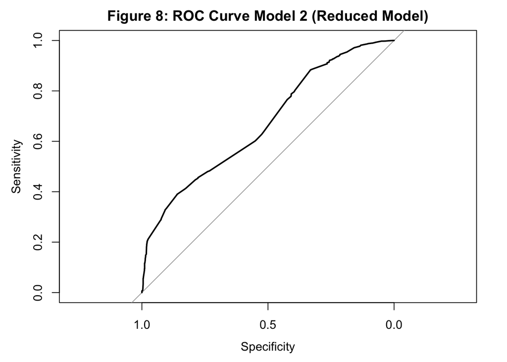

```r
roc2  <- roc(terror2019$success, probs2)
plot(roc2, main = "Figure 8: ROC Curve Model 2 (Reduced Model)")
```

```r
best2 <- coords(roc2, "best", ret = c("threshold", "sensitivity", "specificity"),
                best.method = "youden")
kable(as.data.frame(best2), digits = 4,
      caption = "Table 13: Best Threshold (Youden) Model 2") %>%
  kable_styling(bootstrap_options = c("striped", "hover"), full_width = FALSE)
```

Table 13: Best Threshold (Youden) Model 2

| threshold | sensitivity | specificity |
| --- | --- | --- |
| 0.8734 | 0.3895 | 0.8607 |

```r
cat("AUC Model 2:", round(auc(roc2), 4), "\n")
```

```
## AUC Model 2: 0.6713
```

### 4.3 Model 3: Minimal Model (Attack Type + Suicide)

```r
model3 <- glm(success ~ attacktype1 + suicide,
              data = terror2019, family = binomial)
```

**Table 14: Coefficients, Odds Ratios, and 95% CI Model 3**

```r
coef_table(model3, title = "Table 14: Model 3 Coefficients, OR, and 95% CI")
```

Table 14: Model 3 Coefficients, OR, and 95% CI

| Predictor | Coefficient | Std.Error | z.value | p.value | OR | CI_lower_95 | CI_upper_95 |
| --- | --- | --- | --- | --- | --- | --- | --- |
| (Intercept) | 0.6691 | 0.0795 | 8.4216 | 0.0000 | 1.9525 | 1.6710 | 2.281500e+00 |
| Attack: Armed Assault | 1.2248 | 0.1031 | 11.8782 | 0.0000 | 3.4036 | 2.7808 | 4.166000e+00 |
| Attack: Bombing/Explosion | 1.0584 | 0.0946 | 11.1889 | 0.0000 | 2.8819 | 2.3942 | 3.468900e+00 |
| Attack: Hijacking | 14.8969 | 219.4094 | 0.0679 | 0.9459 | 2948919.1858 | 0.0000 | 1.703427e+193 |
| Attack: Barricade Incident | 3.4291 | 1.0114 | 3.3903 | 0.0007 | 30.8475 | 4.2489 | 2.239546e+02 |
| Attack: Kidnapping | 3.5381 | 0.3015 | 11.7359 | 0.0000 | 34.4001 | 19.0521 | 6.211190e+01 |
| Attack: Facility Attack | 2.9737 | 0.2734 | 10.8785 | 0.0000 | 19.5645 | 11.4495 | 3.343120e+01 |
| Attack: Unarmed Assault | 1.4855 | 0.3818 | 3.8904 | 0.0001 | 4.4174 | 2.0900 | 9.336700e+00 |
| Attack: Unknown | 0.8842 | 0.1115 | 7.9305 | 0.0000 | 2.4211 | 1.9459 | 3.012500e+00 |
| Suicide Attack: Yes | -0.0752 | 0.1747 | -0.4306 | 0.6667 | 0.9275 | 0.6587 | 1.306200e+00 |

**Confusion Matrix and Performance Metrics Model 3:**

```r
probs3 <- predict(model3, type = "response")
pred3  <- ifelse(probs3 > 0.5, 1, 0)
cm3    <- table(Predicted = pred3, Actual = terror2019$success)
xkabledply(cm3, title = "Confusion Matrix Model 3")
```

Confusion Matrix Model 3

| 0 | 1 |
| --- | --- |
| 1206 | 7330 |

```r
metrics3 <- conf_metrics(pred3, terror2019$success, "Model 3 (Minimal)")
kable(metrics3, caption = "Table 15: Performance Metrics Model 3") %>%
  kable_styling(bootstrap_options = c("striped", "hover"), full_width = FALSE)
```

Table 15: Performance Metrics Model 3

| Model | Accuracy | Sensitivity | Specificity | Precision | F1_Score |
| --- | --- | --- | --- | --- | --- |
| Model 3 (Minimal) | 0.8587 | 1 | 0 | 0.8587 | 0.924 |

**ROC Curve and AUC Model 3:**

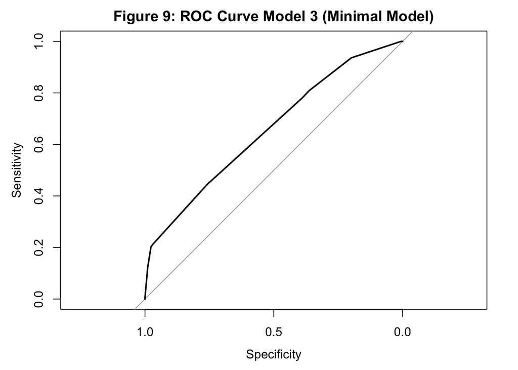

```r
roc3  <- roc(terror2019$success, probs3)
plot(roc3, main = "Figure 9: ROC Curve Model 3 (Minimal Model)")
```

```r
best3 <- coords(roc3, "best", ret = c("threshold", "sensitivity", "specificity"),
                best.method = "youden")
kable(as.data.frame(best3), digits = 4,
      caption = "Table 16: Best Threshold (Youden) Model 3") %>%
  kable_styling(bootstrap_options = c("striped", "hover"), full_width = FALSE)
```

Table 16: Best Threshold (Youden) Model 3

| threshold | sensitivity | specificity |
| --- | --- | --- |
| 0.8648 | 0.4517 | 0.7521 |

```r
cat("AUC Model 3:", round(auc(roc3), 4), "\n")
```

```
## AUC Model 3: 0.6566
```